# abeprojec

Kevin Lee

3/19/2020

Team member: Kevin Lee

The dataset is based on NYC yellow taxi cap. Total of 132 files, 2009-01 to 2019-12. (Link https://www1.nyc.gov/site/tlc/about/tlc-trip-record-data.page) The data is gathered with bash scrip with wget command to a personal computer. Due to the size of the dataset, the Purdue scholar is not suitable due to space limitation.

```r
taxi <-read.csv("/Users/taesuplee/taxi_data/yellow_tripdata_2017-06.csv")
object.size(taxi)
```

```
## 1378007032 bytes
```

```r
table(taxi$passenger_count)
```

```
##
##       0       1       2       3       4       5       6       7       8       9
##     548 6933189 1385066  406162  187979  455753  288220      26      30      20
```

```r
mean(taxi$trip_distance)
```

```
## [1] 2.978617
```

it takes about 1.3 GB of memory for 1 file. Cannot load 10 year of data to a PC.

Due to too many of 0 distance, the histogram shows very very skewed. Only 1 bar is visible compared to other data. Dataset requires some cleaning.

```r
head(table(taxi$trip_distance))
```

```
##
##     0  0.01  0.02  0.03  0.04  0.05
## 64520  3010  2192  1898  1637  1429
```

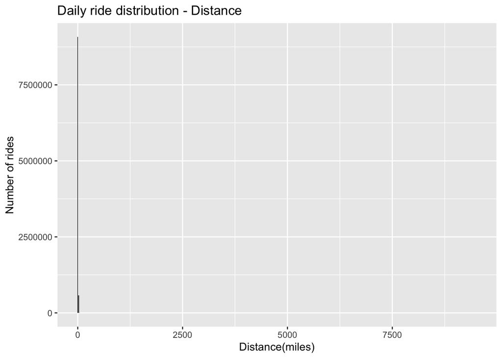

```r
ggplot(taxi, aes(trip_distance)) + geom_histogram(binwidth  = 20) + labs(title =  "Daily ride distribution - Distance") +xlab("Distance(miles)") + ylab("Number of rides")
```

One month data analysis with R. Load the csv to R env. then perform calculation within R space.

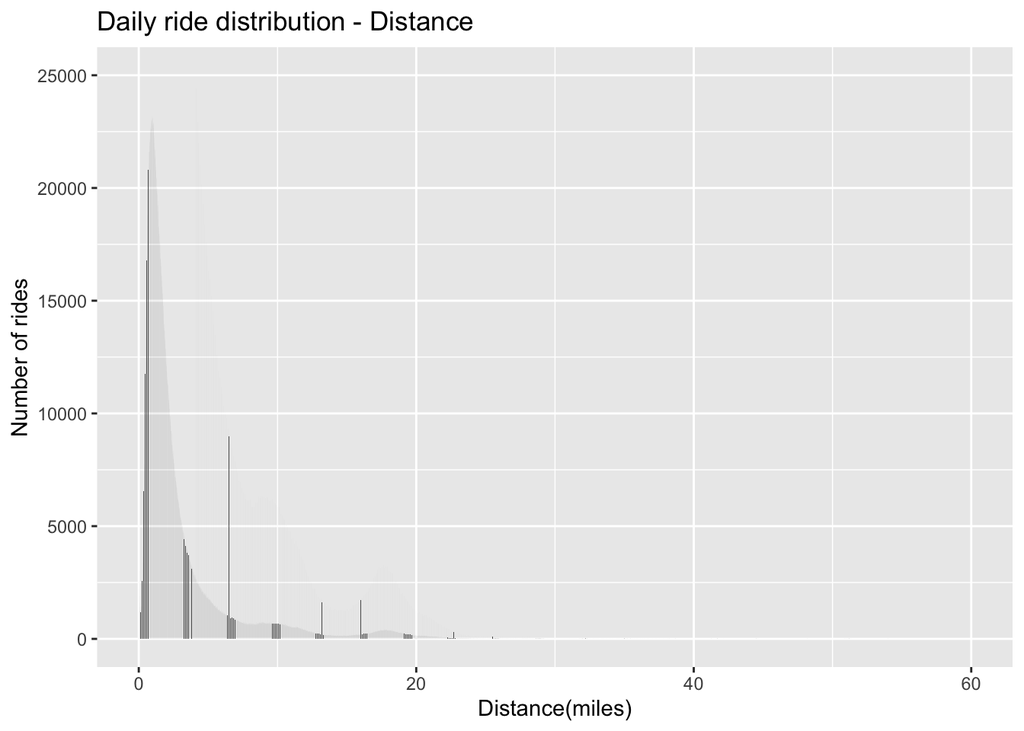

```r
#taxi_dist =taxi$trip_distance

ggplot(taxi, aes(trip_distance)) + geom_histogram(binwidth = 0.001) +xlim(c(0,60)) + ylim(c(0,25000))+ labs(title =  "Daily ride distribution - Distance") +xlab("Distance(miles)") + ylab("Number of rides")
```

```r
length(taxi$passenger_count)
```

```
## [1] 9656993
```

```r
taxi$tpep_pickup_datetime= strtrim(taxi$tpep_pickup_datetime, 10)

tapply(taxi$passenger_count, taxi$tpep_pickup_datetime, mean, na.rm=T)
```

```
## 2017-06-01 2017-06-02 2017-06-03 2017-06-04 2017-06-05 2017-06-06 2017-06-07
##   1.603088   1.615402   1.679658   1.671519   1.604374   1.595261   1.598114
## 2017-06-08 2017-06-09 2017-06-10 2017-06-11 2017-06-12 2017-06-13 2017-06-14
##   1.599391   1.616047   1.683183   1.674893   1.609348   1.599265   1.597475
## 2017-06-15 2017-06-16 2017-06-17 2017-06-18 2017-06-19 2017-06-20 2017-06-21
##   1.602344   1.616375   1.679516   1.673529   1.607643   1.604536   1.608196
## 2017-06-22 2017-06-23 2017-06-24 2017-06-25 2017-06-26 2017-06-27 2017-06-28
##   1.598858   1.623030   1.680020   1.652178   1.620916   1.604177   1.601873
## 2017-06-29 2017-06-30
##   1.604503   1.623556
```

The table shows the average passenger count per day 2017-06.

```r
tapply(taxi$trip_distance, taxi$tpep_pickup_datetime, mean, na.rm=T)
```

```
## 2017-06-01 2017-06-02 2017-06-03 2017-06-04 2017-06-05 2017-06-06 2017-06-07
##   2.889964   2.894732   2.859761   3.322315   3.072319   2.814036   2.885455
## 2017-06-08 2017-06-09 2017-06-10 2017-06-11 2017-06-12 2017-06-13 2017-06-14
##   2.957047   2.939563   2.874861   3.338410   3.014607   2.730345   2.849430
## 2017-06-15 2017-06-16 2017-06-17 2017-06-18 2017-06-19 2017-06-20 2017-06-21
##   2.942021   2.956294   2.860081   3.259831   2.979771   3.004981   2.907504
## 2017-06-22 2017-06-23 2017-06-24 2017-06-25 2017-06-26 2017-06-27 2017-06-28
##   2.935198   2.897129   2.935450   3.596096   3.183072   2.943887   2.973727
## 2017-06-29 2017-06-30
##   2.969742   2.922195
```

The table shows the average distance traveled per day 2017-06.

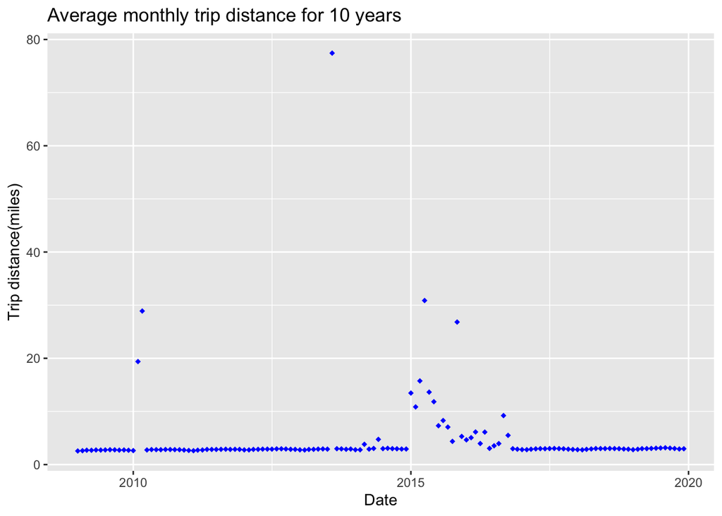

```r
totalavgdist <-read.csv("/Users/taesuplee/taxi_data/totaldist.txt",header=F, sep=" ")
totalavgdist <-as.data.frame(totalavgdist)
colnames(totalavgdist) <- c('date','avgdist')
totalavgdist$date <- as.Date(as.character(totalavgdist$date), format='%Y%m%d')

ggplot(totalavgdist, aes(x= date,y= avgdist))+
  geom_point(shape=18, color="blue")+
   labs(title =  "Average monthly trip distance for 10 years")+xlab("Date")+ylab("Trip distance(miles)")
```

Average distance is computed within shell envrionment again. Awk commend is used to get distance data and average the distance data. All the output is collected to txt file. Once the operation is completed, the txt file is loaded into R to create a plot. This operation is performed on a PC.

#!/bin/zsh for year in {09..19}; do for month in {01..12}; do #Average distance of rides per month cat yellow_tripdata_20$year-$month.csv | awk -F, ’BEGIN{} {avgdis = avgdis+ $5} END{print avgdis/NR}' >> 20$year-avg.txt

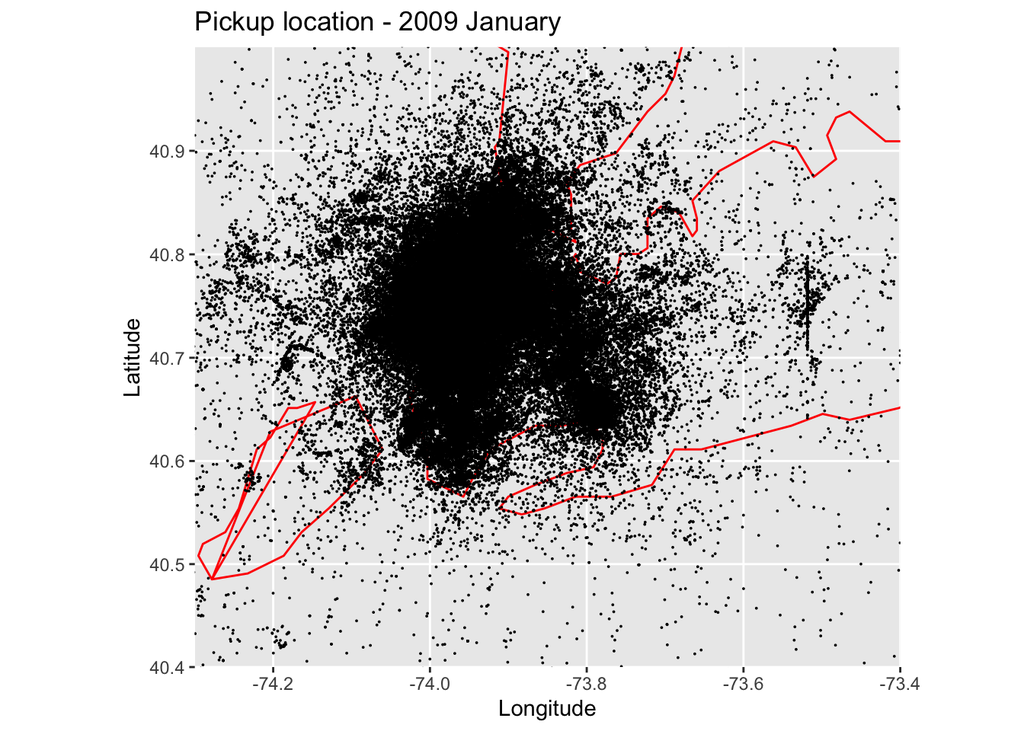

```r
rides <-read.csv("/Users/taesuplee/taxi_data/route_09-01.csv", header=F, sep=" ")
states <- map_data("state")
nyc <- subset(states, region %in% c("new york"))
ny_red<-ggplot(data=nyc)+geom_polygon(data = nyc, aes(x=long, y=lat, group= group),
                                      fill =NA, color="red")+coord_map(xlim = c(-74.3, -73.4),ylim = c(40.40, 41.0)) + labs(title =  "Pickup location - 2009 January")+xlab("Longitude") + ylab("Latitude")

ny_red+geom_point(data= rides, aes(x=rides$V7, y= rides$V8), color="black",size=.000000000001)
```

Performed plotting 1 month(09-2001) pickup locations against the NY manhattan map. Due to high activity for 30 days, the NY manhattan map is complete black.

#!/bin/zsh for year in {09..19}; do for month in {01..12}; do sed -e “s//g” yellow_tripdata_20$year-$month.csv > 20$year-$month.csv #extract routes info for each month 1 - 30th 0900 to 1200 filename=20${year}-${month}.csv year=$year month=$month awk -F, -v month=“$month" -v year="$year” -v filename=“$filename” ‘{gsub(“-”, "“,$2);gsub(” “,”“,$2);gsub(”:“,”",$2)} 20'$year’‘$month’01090000 <= $2 && 20'$year’‘$month’30120000 >= $2’ $filename > route_$year-$month.csv

```r
daily <-read.csv("/Users/taesuplee/taxi_data/daily_rides.txt", sep= " ", colClasses = c("integer", "Date"), header = TRUE)
```

Daily taxi rides were performed in Z shell envrionment. Below commands were used. #!/bin/zsh for year in {09..19}; do for month in {01..12}; #for number of taxi rides on each day #cat yellow_tripdata_20$year-$month.csv | awk -F, ‘{print $2}’ |awk -F" " ‘{print $1}’| sort | uniq -c | sort -k 2,2 >> daily_rides.txt

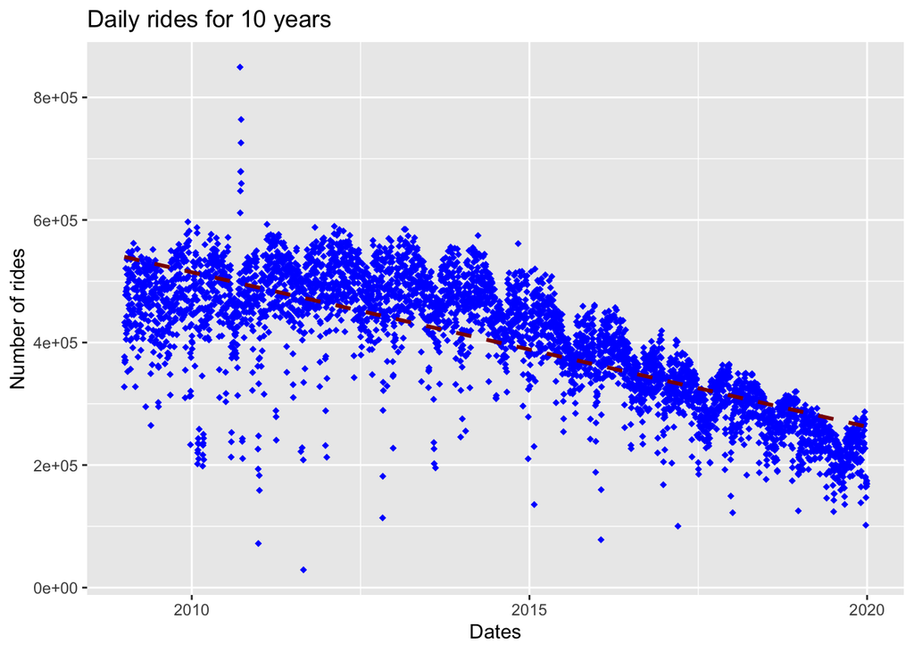

```r
ggplot(daily, aes(x= Dates,y= Rides))+
  geom_point(shape=18, color="blue")+
  geom_smooth(method=lm, se= FALSE, linetype="dashed", color="darkred", fill="blue") + labs(title =  "Daily rides for 10 years")+xlab("Dates") + ylab("Number of rides")
```

```r
head(daily)
```

```
##    Rides      Dates
## 1 327625 2009-01-01
## 2 376708 2009-01-02
## 3 432710 2009-01-03
## 4 367525 2009-01-04
## 5 370901 2009-01-05
## 6 427394 2009-01-06
```

```r
monthly <- aggregate( x= daily$Rides, by=list(format(daily$Dates ,"%Y-%m")) , FUN="mean")
colnames(monthly) <- c('monthYear','monthlyValue')
monthly$monthYear <-paste0(monthly$monthYear,"-01")
monthly$monthYear <- as.Date(monthly$monthYear)
head(monthly)
```

```
##    monthYear monthlyValue
## 1 2009-01-01     454594.0
## 2 2009-02-01     477861.5
## 3 2009-03-01     464108.7
## 4 2009-04-01     476492.8
## 5 2009-05-01     477300.4
## 6 2009-06-01     472808.3
```

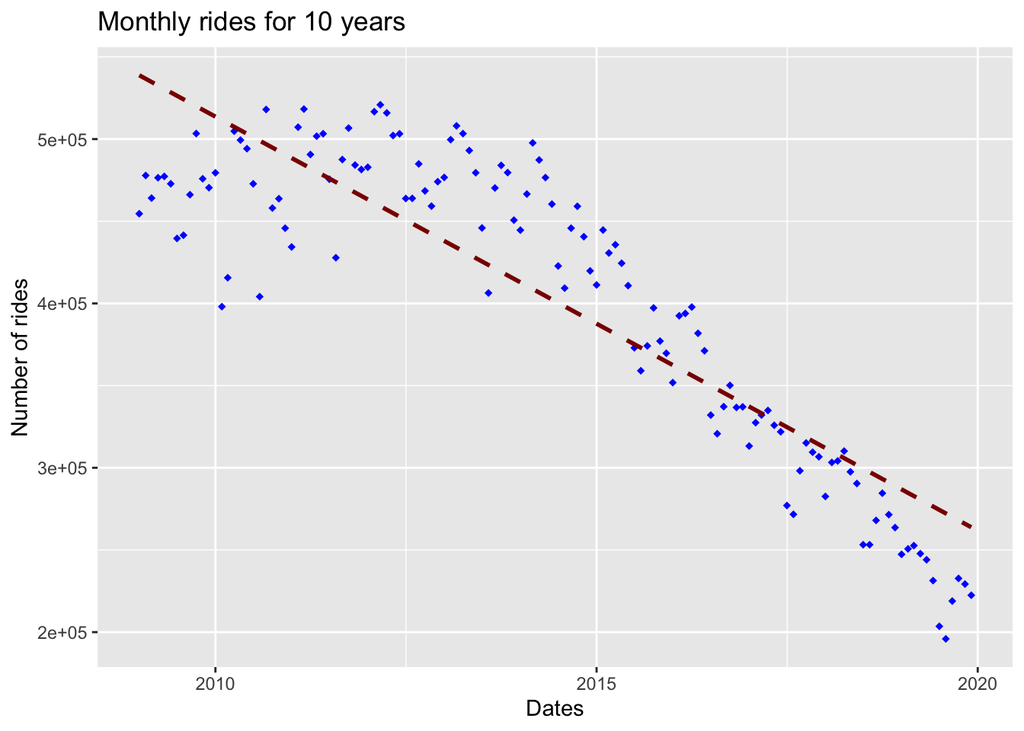

```r
ggplot(monthly, aes(x= monthYear ,y= monthlyValue))+
  geom_point(shape=18, color="blue")+
  geom_smooth(method=lm, se= FALSE, linetype="dashed", color="darkred", fill="blue") + labs(title =  "Monthly rides for 10 years") +xlab("Dates") + ylab("Number of rides")
```

```r
avgdist <-list.files(path="/Users/taesuplee/taxi_data", pattern = "*-avg.txt", full.names = T)

datalist = lapply(avgdist, function(x)read.table(x, header=F))
#avgdate <- seq(as.Date("2009-01"), as.Date("2019-12"), by="month")
```

Commputed the monthly average with shell, awk command. #!/bin/zsh for year in {09..19}; do for month in {01..12}; do #Average distance of rides per month cat yellow_tripdata_20$year-$month.csv | awk -F, ’BEGIN{} {avgdis = avgdis+ $5} END{print avgdis/NR}' >> 20$year-avg.txt